# Project Proposal: Predicting Which Employees Will Quit IBM and Why

Data Science AA Group 8 (Aisling, Antoine, Jessie, Joe, Magno, and Martin)

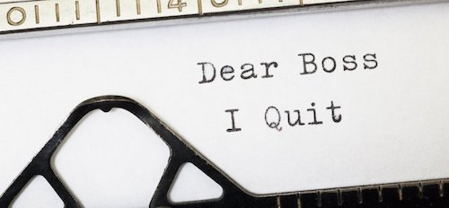

### Business Problem

IBM has recently faced a record number of employee departures from their company. This is deterimental to profit, productivity, and morale of the company. Worst of all, it is disruptive and makes the work of hiring even more challenging.

We want to predict which employees will leave this year due to voluntary resignation. If we do this successfully, IBM can try to prevent the departure of current employees or attempt to fill their spots before they leave.

Most importantly, we want to figure out the profiles of certain employees in their departure. With this information, the leadership of IBM can identify who is at risk of leaving and effectively motivate them to stay.

### Three Step Process

We see three essential steps to performing the analysis we want.

#### Step 1: Format and clean the data

- Re-format the data and clean empty variables
- Perform dimensionality reduction to create richer, more meaningful fields

#### Step 2: Perform data analysis to predict which employees will leave

- Use LASSO to further reduce the fields to our final set
- Create a predictive model to determine which employees will leave

#### Step 3: Output final data

- Run the model on the test data to output attrition predictions
- Describe clusters of employees that may depart

### Sample of Data

The challenge with our data is going to be to reduce the 32 variables to our final set. We sourced our data from [this Kaggle dataset](https://www.kaggle.com/dgokeeffe/ibm-hr-wmore-rows).

Important to note: Values in this project may be partially fictitious due to legal consequences for HR data leakage.

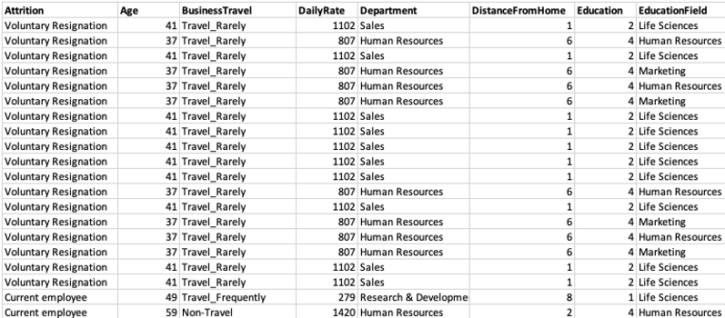

### Data Dictionary

Per the online documentation for the dataset, the definitions are as follows:

[output not shown]